# Housing Price Prediction EDA sample

Bernardus Ari Kuncoro

# Problem Description

The most difficult part on pricing a house is that, there are many variables that involved. Those may include locations, year the house built, accessability to the public places, and so on. The end goal is to predict the sales price for each house. For each ID in the test set, you must predict the value of the SalePrice variable.

But for this class, we will just perform Exploratory Data Analysis.

Data was taken from this Kaggle website for our learning purpose on IYKRA DATA MBA Program. Here is the link source:

https://www.kaggle.com/c/house-prices-advanced-regression-techniques.

Data contains 79 variables which can be seen the description here:

https://www.kaggle.com/c/house-prices-advanced-regression-techniques/data

# Loading Packages

```r
#Install if the package doesn't exist
#install.packages('DataExplorer')
library(DataExplorer)
#install.packages('corrplot')
library(corrplot)
library(tidyverse)
```

# Loading Dataset

```r
housing_train <- read.csv("dataset/train.csv", stringsAsFactors = F)
housing_test <- read.csv("dataset/test.csv", stringsAsFactors = F)
```

# Initial Data Checking

## Variables

The very first thing that you’d want to do in your EDA is checking the dimension of the input dataset and the time of variables.

```r
plot_str(housing_train)
```

[interactive chart not shown]

## Checking Data Size

```r
dim(housing_train)
```

```
[1] 1460   81
```

```r
dim(housing_test)
```

```
[1] 1459   80
```

## Checking Data Types

```r
str(housing_train)
```

```
'data.frame':   1460 obs. of  81 variables:
 $ Id           : int  1 2 3 4 5 6 7 8 9 10 ...
 $ MSSubClass   : int  60 20 60 70 60 50 20 60 50 190 ...
 $ MSZoning     : chr  "RL" "RL" "RL" "RL" ...
 $ LotFrontage  : int  65 80 68 60 84 85 75 NA 51 50 ...
 $ LotArea      : int  8450 9600 11250 9550 14260 14115 10084 10382 6120 7420 ...
 $ Street       : chr  "Pave" "Pave" "Pave" "Pave" ...
 $ Alley        : chr  NA NA NA NA ...
 $ LotShape     : chr  "Reg" "Reg" "IR1" "IR1" ...
 $ LandContour  : chr  "Lvl" "Lvl" "Lvl" "Lvl" ...
 $ Utilities    : chr  "AllPub" "AllPub" "AllPub" "AllPub" ...
 $ LotConfig    : chr  "Inside" "FR2" "Inside" "Corner" ...
 $ LandSlope    : chr  "Gtl" "Gtl" "Gtl" "Gtl" ...
 $ Neighborhood : chr  "CollgCr" "Veenker" "CollgCr" "Crawfor" ...
 $ Condition1   : chr  "Norm" "Feedr" "Norm" "Norm" ...
```

[output cut: 67 more lines]

Getting rid of the IDs but keeping the test Ids in a vector. These are needed to compose the submission file

```r
test_labels <- housing_test$Id
housing_test$Id <- NULL
housing_train$Id <- NULL
```

```r
housing_test$SalePrice <- NA
all <- rbind(housing_train, housing_test)
dim(all)
```

```
[1] 2919   80
```

Without the Id’s, the dataframe consists of 79 predictors and our response variable SalePrice.

## Checking Missing value

It’s very important to see if the input data given for Analysis has got Missing values before diving deep into the analysis.

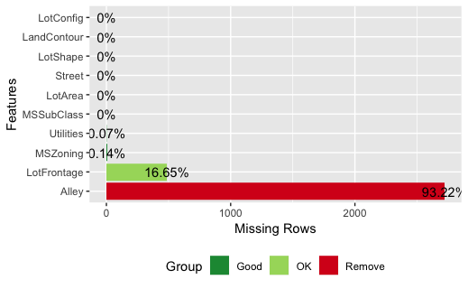

```r
plot_missing(all[,c(1:10)])
```

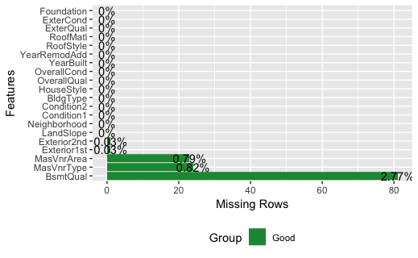

```r
plot_missing(all[,c(11:30)])
```

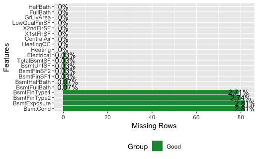

```r
plot_missing(all[,c(31:50)])
```

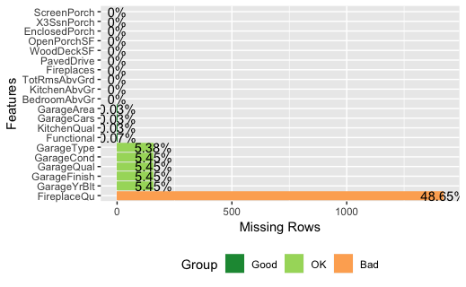

```r
plot_missing(all[,c(51:70)])
```

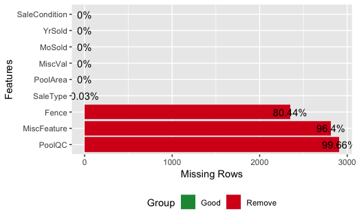

```r
plot_missing(all[,c(71:79)])
```

By checking missing value, we might remove some columns unnessecary because of more than 50% missing such as Fence, MiscFeature, PoolQC,

# Variation WITHIN each variable

## Histogram

First we try the histogram of SalesPrice

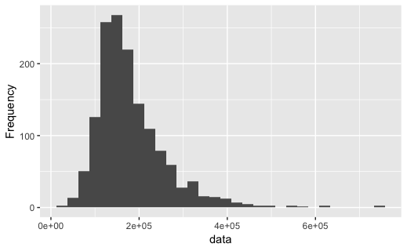

```r
plot_histogram(all$SalePrice)
```

```r
summary(all$SalePrice)
```

```
   Min. 1st Qu.  Median    Mean 3rd Qu.    Max.    NA's
  34900  129975  163000  180921  214000  755000    1459
```

Before we begin to implement all the variable visualization (which are too tedious), we need to select the importance feature that can affect Sales Prediction. We’ll use correlation.

```r
numericVars <- which(sapply(all, is.numeric)) #index vector numeric variables
numericVarNames <- names(numericVars) #saving names vector for use later on
cat('There are', length(numericVars), 'numeric variables')
```

```
There are 37 numeric variables
```

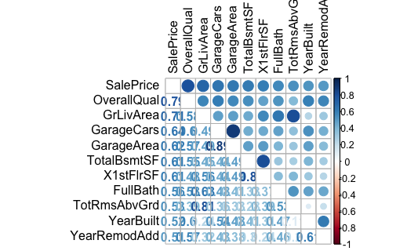

```r
all_numVar <- all[, numericVars]
cor_numVar <- cor(all_numVar, use="pairwise.complete.obs") #correlations of all numeric variables
#sort on decreasing correlations with SalePrice
cor_sorted <- as.matrix(sort(cor_numVar[,'SalePrice'], decreasing = TRUE))
 #select only high corelations
CorHigh <- names(which(apply(cor_sorted, 1, function(x) abs(x)>0.5)))
cor_numVar <- cor_numVar[CorHigh, CorHigh]
corrplot.mixed(cor_numVar, tl.col="black", tl.pos = "lt")
```

Top 10 numeric variables are - OverallQual - GrLivArea - GarageCars - GarageArea - TotalBsmtSF - X1stFlrSF - FullBath - TotRmsAbvGrd - YearBuilt - YearRemodAdd

# Plot Histogram

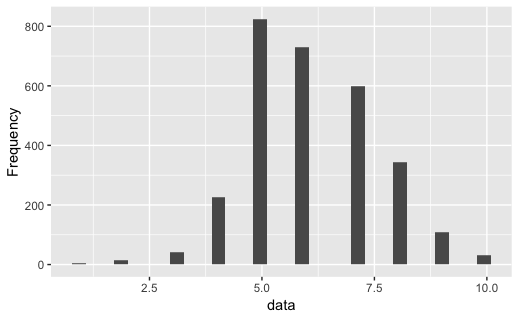

```r
plot_histogram(all$OverallQual)
```

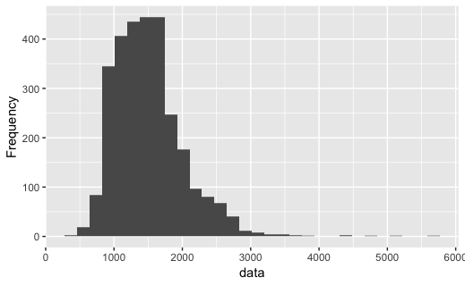

```r
plot_histogram(all$GrLivArea)
```

# Covarian between Variables

## Two continuous Variables

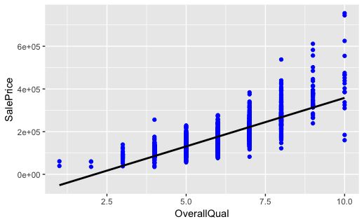

```r
ggplot(data=all[!is.na(all$SalePrice),], aes(x=OverallQual, y=SalePrice))+
        geom_point(col='blue') + geom_smooth(method = "lm", se=FALSE, color="black", aes(group=1))
```

Using plot_scatterplot function.

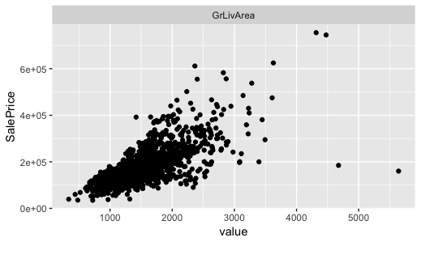

```r
plot_scatterplot(all[!is.na(all$SalePrice),c("SalePrice","GrLivArea")], by="SalePrice")
```

Using plot_scatterplot function.

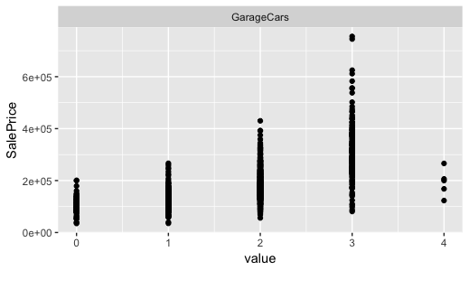

```r
plot_scatterplot(all[!is.na(all$SalePrice),c("SalePrice","GarageCars")], by="SalePrice")
```

## One Continuous One Category

MSZoning and SalePrice

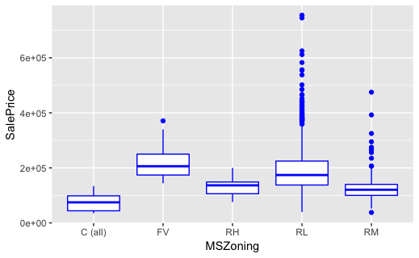

```r
ggplot(data=all[!is.na(all$SalePrice),], aes(x=factor(MSZoning), y=SalePrice))+
        geom_boxplot(col='blue') + labs(x='MSZoning')
```

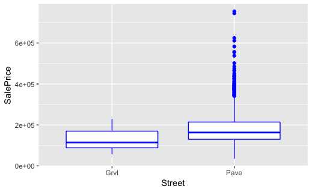

```r
ggplot(data=all[!is.na(all$SalePrice),], aes(x=factor(Street), y=SalePrice))+
        geom_boxplot(col='blue') + labs(x='Street')
```

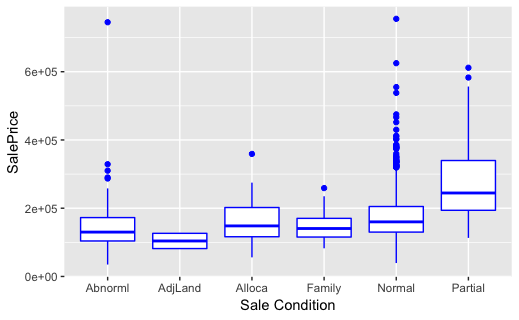

```r
ggplot(data=all[!is.na(all$SalePrice),], aes(x=factor(SaleCondition), y=SalePrice))+
        geom_boxplot(col='blue') + labs(x='Sale Condition')
```

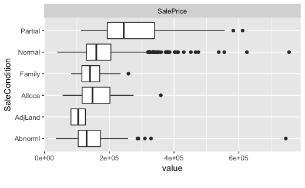

```r
plot_boxplot(all[!is.na(all$SalePrice),c("SalePrice","SaleCondition")],by="SaleCondition")
```

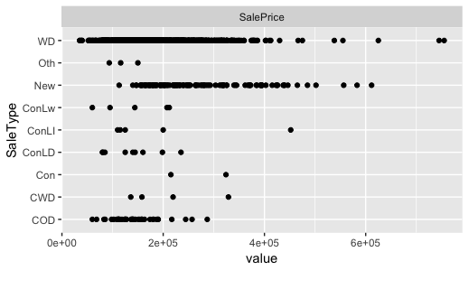

```r
plot_scatterplot(all[!is.na(all$SalePrice),c("SalePrice","SaleType")],by="SaleType")
```

# Summary

Please continue!